# HELPmiss (Data Verbs) Activity

Alvin Chen

## Set Up:

```r
rm(list = ls())     # clean up your R environment

# load packages
library(tidyverse)  # includes lots of data verbs like `group_by()` and `summarise()`
library(mosaicData) # includes the `HELPmiss` data set


# Load the `HELPmiss` data set into our RStudio environment
data("HELPmiss", package = "mosaicData")
```

## Helpful links:

- Look though the DC Textbook for `tidyverse` functions.
- Check out some of these RStudio cheat sheets:
  - https://www.rstudio.com/wp-content/uploads/2015/02/data-wrangling-cheatsheet.pdf
  - https://www.rstudio.com/resources/cheatsheets/
  - https://s3.amazonaws.com/assets.datacamp.com/blog_assets/Tidyverse+Cheat+Sheet.pdf

## Task 1: Data Description

*Write several sentences (or a bullet list) describing the HELP Study and the resulting `HELPmiss` data. Your description should investigate basic data provenance (e.g., Who, What, When, Where, Why, How), explain the setting for the data, specify what each case represents in the data, and remark on inclusion/exclusion criteria.*

- investigate by searching R help documentation
- there’s a research paper cited where additional detail is provided
- The HElP study was an experiment that incorporated adults that cane from a detoxification unit who did not have a primary care physician. A motivation intervention and a multidisciplinary test or standard car were assigned to each patient at random. The ultimate goal of this study was to link them to primary medical care. One of the data sets that stemmed from the HELP study was the HELPmiss data set. The HELPmiss data set incoorperated adults that spoke English or Spanish. Given the choice of alcohol, heroin, and cocain, they were asked to report which substance was their first or second choice. Within thei location it was determined id they were near a primary care clinic which they would be reffered to or if they were homeless. Those that already had care, significant dimentia, lacked conctact information, pregnant, or are leaving the area were not included within the dataset. The adults were interviewed when during their detoxification and received follow up interviews that took place every 6 months for 2 years. Each case in the data set included adults that met the crieteria (spoke English or Spanish, Their choices of drugs, and location) and provided data that was requested for the study.

## Task 2: Basic Summaries

*Produce one or more R expressions involving `summarize()` and `HELPmiss` to address each of the following prompts.*

1. number of people (cases) in `HELPmiss` study

```r
#Your code here
num_ppl <-
  HELPmiss %>%
  summarize(num_ppl = n())
```

2. total number of times in the past 6 months entered a detox program (measured at baseline) for all the people in `HELPmiss`.

```r
#Your code here
num_detox <-
  HELPmiss %>%
  summarize(total_times = sum(e2b, na.rm=TRUE))
```

3. mean time (in days) to first use of any substance post-detox for all the people in `HELPmiss`

```r
#Your code here
mean_time_after_detox <-
  HELPmiss %>%
  summarize(mean_time = mean(daysanysub, na.rm=TRUE)) #549
```

## Task 3: Group Summaries

*Repeat task 2 above, but add code chunks to calculate result group-by-group according to each prompt (i.e. each promt should have three statements for each of the three prompts in task 2). Be sure to show all R code and write a sentence or two about what you observe in the results. Remember, you can add multiple statistics inside `summary`.*

- males versus females
- homeless or not
- substance
- break down the homeless versus housed further, by sex
- homeless versus housed broken down by substance

### males versus females

```r
#Your code here
male_vs_female <-
  HELPmiss %>%
  group_by(female) %>%
  summarize(num_ppl = n())
```

### homeless or not

```r
#Your code here
yes_or_no_homeless <-
  HELPmiss %>%
  group_by(homeless) %>%
  summarize(num_ppl = n())
```

### substance

```r
#Your code here
substance_group <-
  HELPmiss %>%
  group_by(substance) %>%
  summarize(num_ppl = n())
```

### homeless versus housed broken down by sex

```r
#Your code here
housing_by_gender <-
  HELPmiss %>%
  group_by(homeless, female) %>%
  summarize(num_cases = n())
```

### homeless versus housed broken down by substance

```r
#Your code here
housing_by_substance <-
  HELPmiss %>%
  group_by(homeless, substance) %>%
  summarize(num_cases = n())
```

## Task 4: Data Visualization & Observations

*Include one or more interesting plots from this data set involving at least 3 variables per plot. Write a few sentences to explain the story that your plot tells about these data. You can expand on the relationships that you studied in Task 2, or you can explore a different group of variables in `HELPmiss` that show something interesting. Remember to use the interactive commands in the console, generate the R commands that will reproduce your plot, and then paste the R commands into an R chunk in the RMarkdown file.*

*Remember, you can use* `esquisser` *or* `mplot` *in your console. But only include the ggplot code in this Rmd document.*

My variables are: age, substance, and treat. FOr this plot, my goal was to focus on the relationship between age and substance use and to dive deeper, I wanted to know within that group, if the adult was refered to a clinic or not. It was interesting to me to see which substance correlated with which age group and of that, amount which age group and substance were randomized to a clinic.

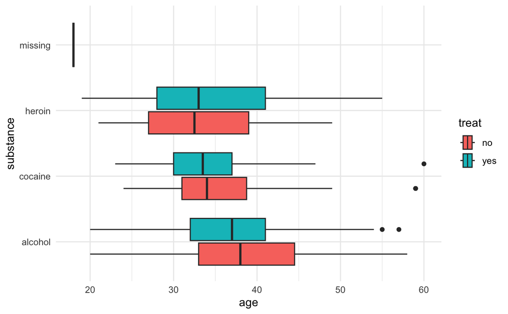

```r
# Your Code here.
ggplot(HELPmiss) +
  aes(x = age, y = substance, fill = treat) +
  geom_boxplot() +
  scale_fill_hue(direction = 1) +
  theme_minimal()
```